# 4.1 DD transect map and stat

TG

2023-01-15

Get my final data, statistic and map:

```r
library(dplyr)
library(tidyr)
library(lubridate)
library(ggplot2)
library(stringr)
library(rfishbase)
library(Hmisc)
library(vegan)
library(mobr)
library(viridis)
library(plotrix)
library(sjmisc)
library(sf)
library(ggspatial)
library(rgeos)
library(maptools)

plot_dir<-"G:\\My Drive\\PHD\\chapter 3 MPA dd\\Meddata-DD\\figures\\4.1 plots"
```

# MEDATA

```r
medata_raw <- readRDS("G:/My Drive/PHD/chapter 3 MPA dd/Meddata-DD/cyprus fix/medata_from_git_after_cyp.Rds") # the original data (not really the row-row one)


medata<-medata_raw # the verstion ill play with
```

## Data cleaning

Remove transects that have only 0 and seems like mistakes:

```r
zero_obs<- medata %>% filter(sp.n == 0)

transect_to_remove<-c("kornati217015286494381202NA",
                      "kornati216815286494381202NA",
                      "kornati216915286494381202NA",
                      "gdor164534866923241672NA")

medata<-medata %>% filter(!unique_trans_id %in% transect_to_remove)
```

Examine the species list:

```r
species<- medata %>% distinct(species)
```

Remove `.spp` species:

```r
Species_to_remove <-species$species[which(str_detect(species$species,".spp")==T)]

medata <-medata %>% filter(!species %in% Species_to_remove)

species<- medata %>% distinct(species,family)
```

Remove cryptic species:

Gobiidae, Blenniidae & Tripterygiidae

```r
Families_to_remove<- c("Gobiidae","Blenniidae","Tripterygiidae")

medata <-medata %>% filter(!family %in% Families_to_remove)

species<- medata %>% distinct(species,family)
```

## fix cyprus coords

the lat and lon of cyprus

```r
medata$lat_n<-ifelse(medata$country=="Cyprus",
                               medata$lon,
                               medata$lat)

medata$lon_n<-ifelse(medata$country=="Cyprus",
                              medata$lat,
                              medata$lon)

medata<-medata %>% select(-lat,-lon) %>%
  rename("lat" = "lat_n","lon" = "lon_n") %>%
  relocate(lat, .after = season) %>%
  relocate(lon,.before = site)

medata<-medata %>% drop_na(protection)
```

## load map

```r
med_seas <- st_read("Med_World_Seas_IHO_v3_MarineRegions/Medit_seas_IHO.shp")
```

### which points in which polygon

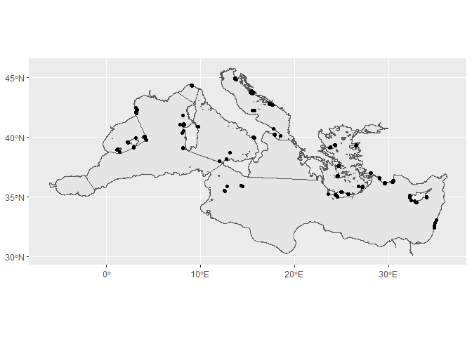

```r
sf_medata<- st_as_sf(medata, coords = c("lon","lat"),crs = "WGS84")

ggplot() +
  geom_sf(data = med_seas) + # plot the polygons first
  geom_sf(data= sf_medata)
```

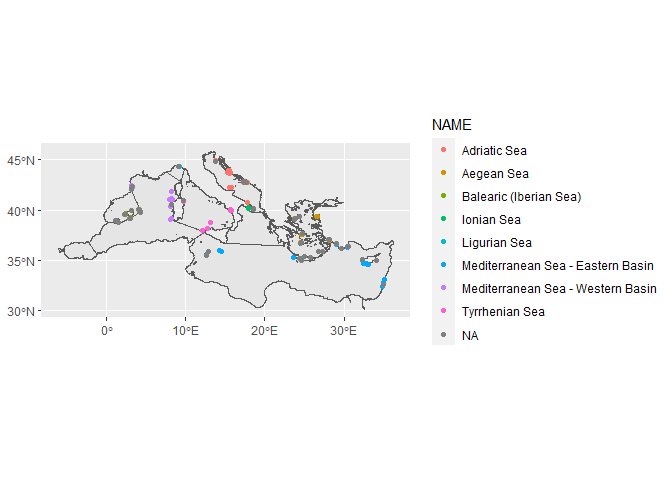

```r
map_n_point <- st_join(sf_medata, med_seas, join = st_within)


ggplot() +
  geom_sf(data = med_seas) + # plot the polygons first
  geom_sf(data= map_n_point,aes(color = NAME))
```

```r
map_n_point %>% filter(is.na(NAME))
```

```
## Simple feature collection with 11353 features and 35 fields
## Geometry type: POINT
## Dimension:     XY
## Bounding box:  xmin: 1.159 ymin: 32.61921 xmax: 34.91514 ymax: 44.85301
## Geodetic CRS:  WGS 84
## # A tibble: 11,353 × 36
##    data.ori…¹ country season site  trans uniqu…² prote…³ enfor…⁴ total…⁵ size.…⁶
##  * <fct>      <fct>   <fct>  <fct> <dbl> <chr>   <lgl>   <fct>     <dbl>   <dbl>
##  1 azz_malt   Italy   autumn lino…   211 linosa… TRUE    1            NA      NA
##  2 azz_malt   Italy   autumn lino…   211 linosa… TRUE    1            NA      NA
##  3 azz_malt   Italy   autumn lino…   211 linosa… TRUE    1            NA      NA
##  4 azz_malt   Italy   autumn lino…   211 linosa… TRUE    1            NA      NA
##  5 azz_malt   Italy   autumn lino…   211 linosa… TRUE    1            NA      NA
##  6 azz_malt   Italy   autumn lino…   211 linosa… TRUE    1            NA      NA
##  7 azz_malt   Italy   autumn lino…   211 linosa… TRUE    1            NA      NA
##  8 azz_malt   Italy   autumn lino…   211 linosa… TRUE    1            NA      NA
##  9 azz_malt   Italy   autumn lino…   211 linosa… TRUE    1            NA      NA
## 10 azz_malt   Italy   autumn lino…   211 linosa… TRUE    1            NA      NA
## # … with 11,343 more rows, 26 more variables: yr.creation <fct>,
## #   age.reserve.yr <fct>, depth <dbl>, tmean <dbl>, sal_mean <dbl>,
## #   pp_mean <dbl>, species <chr>, sp.n <dbl>, sp.length <dbl>, family <fct>,
## #   exotic <lgl>, FoodTroph <dbl>, FoodSeTroph <dbl>, a <dbl>, b <dbl>,
## #   geometry <POINT [°]>, NAME <chr>, ID <chr>, Longitude <dbl>,
## #   Latitude <dbl>, min_X <dbl>, min_Y <dbl>, max_X <dbl>, max_Y <dbl>,
## #   area <dbl>, MRGID <dbl>, and abbreviated variable names ¹data.origin, …
```

```r
rm(sf_medata)
rm(map_n_point)
```

what happens is that I have many points that fall on land… I used for loop to fix it:

```r
med_seas_sp <- as_Spatial(med_seas)  #create a version of the shp in sp

for (i in 1:nrow(med_seas_sp)) {

  region <- med_seas_sp[i,]  #select each region
  region_bf <- gBuffer(region, width = 0.01) #make a buffer around the region
  other_regs <- med_seas_sp[-i,]  #select all other regions
  region_bf_land <- gDifference(region_bf, other_regs) #delete part of the buffer overlapping other regions
  region_bf_land <- spChFIDs(region_bf_land, paste(i))  #indicate ID of each feature
  region_bf_land <-  SpatialPolygonsDataFrame(region_bf_land, region@data) #give back the info stollen by evil functions

  if(i == 1){
    med_seas_bf <- region_bf_land #for the first loop
  }else{
    med_seas_bf <- spRbind(med_seas_bf, region_bf_land) #for teh other loopa
  }

  print(i)
}
```

```
## [1] 1
```

```
## [1] 2
```

```
## [1] 3
```

```
## [1] 4
```

```
## [1] 5
```

```
## [1] 6
```

```
## [1] 7
```

```
## [1] 8
```

```
## [1] 9
```

```
## [1] 10
```

```
## [1] 11
```

```r
#get the info of see for each point

medata_sp <- as.data.frame(medata) #make a spatialPointsDataFrame object
coordinates(medata_sp) <- ~ lon + lat  #inform lon and lat to transform into spatial object
proj4string(medata_sp) <- proj4string(med_seas_bf) #inform sp points obj coordinate info system
points_regions <- over(medata_sp, med_seas_bf) #extract bassin info for each point
medata_sp$Basin <- points_regions$NAME
medata_sp$colour <- as.integer(as.factor(medata_sp$Basin))
unique(is.na(medata_sp$Basin))
```

```
## [1] FALSE
```

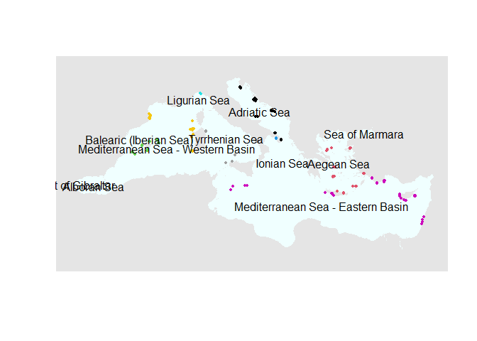

```r
plot(med_seas_bf,col = 'azure', border = NA, bg = 'grey90')
plot(medata_sp, add = T, pch = 19, cex = 0.5, col = medata_sp$colour)
text(med_seas_bf$Longitude, y = med_seas_bf$Latitude,med_seas_bf$NAME)
```

cool!

now ill add to my non-spatiat medata the basin

```r
basin <-medata_sp@data

basin <- basin %>%  select(Basin,unique_trans_id) %>% distinct(unique_trans_id,.keep_all = T)

medata<-left_join(medata,basin)
medata<-medata %>% relocate(Basin,.after = country)
```

Create alternative basin division which:

- add the `Ionian Sea` to the `Adriatic Sea`
- add the `Ligurian Sea` to the `Mediterranean Sea - Western Basin`
- separate Israel or Cyprus to the `Levantine Sea`

```r
medata<-medata %>% mutate(alt_basin = Basin) %>% relocate(alt_basin,.after = Basin)

medata$alt_basin<-ifelse(medata$Basin == "Ionian Sea",
                         "Adriatic Sea",
                         medata$alt_basin)

medata$alt_basin<-ifelse(medata$Basin == "Ligurian Sea",
                         "Mediterranean Sea - Western Basin",
                         medata$alt_basin)

medata$alt_basin<-ifelse(medata$country %in% c("Israel","Cyprus"),
                         "Levantine Sea",
                         medata$alt_basin)
```

fix some point in turkey that needed to be added to the levent

```r
medata$alt_basin<-ifelse(medata$country == "Turkey" & medata$lon > 29.472579,"Levantine Sea",medata$alt_basin)
```

change `TRUE` & `FALSE` variables

```r
medata$protection<-ifelse(medata$protection==TRUE,"Protected","Not protected")

medata$exotic<-ifelse(medata$exotic==TRUE,"Invasive","Native")
```

# save medata

```r
#saveRDS(medata,"clean_dd_medata.rdata")
```

## some data statistics

count transects per location

```r
transect_per_site<-medata %>%
    group_by(country,site,protection,enforcement) %>%
  summarise("number_of_trans"= n_distinct(unique_trans_id))
```

Get Transect per:

1. country
2. country & protection
3. protecion (Yes/no)
4. Enforcment level
5. basin
6. alternative basin
7. alternative basin + protection

```r
#1
transect_per_country<-medata %>% group_by(country) %>% summarise("number_of_trans"= n_distinct(unique_trans_id))

#2
transect_per_country_pro<-medata %>% group_by(country,protection) %>% summarise("number_of_trans"= n_distinct(unique_trans_id))
#3

transect_per_protection<-medata %>% group_by(protection) %>% summarise("number_of_trans"= n_distinct(unique_trans_id))
#4

transect_per_enforcment<-medata %>% group_by(enforcement) %>% summarise("number_of_trans"= n_distinct(unique_trans_id))

#5

transect_per_basin <- medata %>% group_by(Basin) %>% summarise("number_of_trans"= n_distinct(unique_trans_id))

#6

transect_per_altbasin <- medata %>% group_by(alt_basin) %>% summarise("number_of_trans"= n_distinct(unique_trans_id))

#7

transect_per_altbasin_protection <- medata %>% group_by(alt_basin,protection) %>% summarise("number_of_trans"= n_distinct(unique_trans_id))
```

## Study site map

get only distinct point with different lat and lon:

```r
unique_coords<-medata %>% distinct(lat,lon,enforcement,protection,.keep_all = T) %>% select(country,site,lat,lon,protection,enforcement)
```

```
## Scale on map varies by more than 10%, scale bar may be inaccurate
```

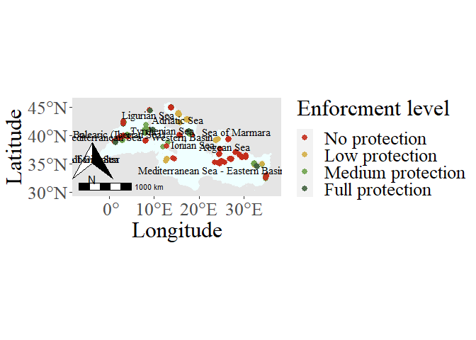

```r
ggplot(unique_coords) +
  geom_sf(data = med_seas$geometry, mapping = aes(),fill= "azure",color = NA) + ##D4ECFF
  geom_point(data =unique_coords,aes(x = lon, y = lat, color = enforcement),
             size = 2.5,alpha = 0.9,position=position_jitter(h=0.06, w=0.06)) +
  xlab("Longitude") +
  ylab("Latitude") +
   annotation_scale(location = "bl", width_hint = 0.4) +
    annotation_north_arrow(location = "bl", which_north = "true",
        pad_x = unit(0.0, "in"), pad_y = unit(0.2, "in"))+
  theme(panel.background = element_rect(fill = "grey90"),##FFFAF7
        text=element_text(size=24, family = "serif"),
        panel.grid.major = element_line(colour = "transparent"))+
    geom_sf_text(data =med_seas, aes(label = med_seas$NAME),
                 family = "serif")+
  scale_color_manual("Enforcment level",values=c("#C42E1C","#D4B04A","#70A34E","#446441"),
                     labels = c("No protection","Low protection","Medium protection","Full protection"))
```

```r
#ggsave(filename = "med_map_v1.pdf", width=15, height=10)
```

`#C42E1C` - red `#D4B04A`- yellow `#70A34E`- light green `#446441` - dark green

Ill take it to QGIS!

### save data

save the unique coordinates data

```r
#saveRDS(unique_coords,"unique_coords.rdata")
#write.csv(unique_coords,"unique_coords.csv")
```

# complexity data

```r
comp_data_raw <-read.csv("G:/My Drive/PHD/chapter 3 MPA dd/Meddata-DD/data/Mediterranean_data_COMPLEX.csv")

lab_fish_data_raw <- read.csv("G:/My Drive/PHD/chapter 3 MPA dd/Meddata-DD/data/Med_analyses_data.csv")

comp_data_raw$X<-NULL
lab_fish_data_raw$X<-NULL
```

unite data frames

```r
colnames(comp_data_raw)
```

```
##  [1] "date"           "year"           "location"       "site_n"
##  [5] "reserve"        "season"         "ID"             "mean_depth"
##  [9] "max_richness"   "max_abundance"  "max_biomass"    "shannon"
## [13] "FunRichness"    "FunEvenness"    "FunDispersion"  "FunOriginality"
## [17] "FunDistinct"    "FunIrregular"   "FunSingular"    "SkyView"
## [21] "SkyView_sd"     "Rugosity"       "SD"             "VerRelief"
## [25] "Slope"          "FractalDim"     "Curvature"      "Neighbors_dist"
## [29] "Max_convexity"  "Max_concavity"  "FreeSpace"      "earth_movers"
```

```r
colnames(lab_fish_data_raw)
```

```
##  [1] "date"             "year"             "season"           "location"
##  [5] "site_n"           "time"             "right_observer"   "left_observer"
##  [9] "visibility"       "direction"        "abundance"        "distance"
## [13] "length"           "species"          "reserve"          "id"
## [17] "observer"         "enforcement"      "new_a"            "new_b"
## [21] "new_id"           "campaign"         "observer_num"     "species_richness"
## [25] "max_richness"     "max_abundance"    "shannon"          "max_biomass"
```

```r
all_data<-left_join(lab_fish_data_raw,comp_data_raw)
```

[output not shown]

keep one observer only

```r
one_observer<-list()
loop<-1
set.seed(1)

for (i in unique(all_data$id)) {

  data <- all_data %>% filter(id == i)

  obs_amount <- length(unique(data$Observer))
  obs_name <- unique(data$observer)
  chosen_obs <- sample(obs_name,1)

  filter_data<-data %>% filter(observer == chosen_obs)
  one_observer[[loop]]<-filter_data
  loop<-loop+1


}

one_observer<- bind_rows(one_observer)
rm(data,filter_data)
```

```r
one_observer <-one_observer %>% select(-right_observer,-left_observer,-ID,-new_a,-new_b, -new_id,-observer_num,-distance,-direction,-campaign) %>% relocate(species,.after = earth_movers) %>%
  relocate(abundance,.after = species) %>%
  relocate(length,.before = abundance)


one_observer<-one_observer %>%  select(-visibility,-time,-max_richness,-max_abundance,-max_biomass,-shannon,-site_n,-season,-year)


one_observer<- one_observer %>% group_by(across(1:30)) %>% summarise("total_abundance"= sum(abundance)) %>% ungroup()
```

[output not shown]

change columns names and values to fit the medata

```r
complexity_clean_data <-one_observer %>% rename("protection" = "reserve",
                                                "site" = "location",
                                                "unique_trans_id" = "id",
                                                "sp.n" = "total_abundance",
                                                "sp.length" = "length")
complexity_clean_data$protection<-ifelse(complexity_clean_data$protection=="In","Protected","Not protected")
```

## save complexity data:

```r
#saveRDS(complexity_clean_data,"complexity_clean_data.rdata")
```